# Steam modelling

```python
import pandas as pd
import numpy as np
import matplotlib.pyplot as plt
import seaborn as sns
import datetime
from collections import defaultdict
from my_functions import regular_comp
from tqdm import tqdm_notebook
import random as random

%config InlineBackend.figure_format = 'retina'
%matplotlib inline
```

```python
from sklearn.model_selection import cross_val_score, cross_val_predict, train_test_split, KFold, GridSearchCV
from sklearn.preprocessing import StandardScaler, PolynomialFeatures, MinMaxScaler, PowerTransformer
from sklearn.linear_model import LinearRegression, Ridge, Lasso, RidgeCV, LassoCV
from sklearn.compose import TransformedTargetRegressor
from sklearn.metrics import roc_curve, auc, confusion_matrix, classification_report, precision_recall_curve, r2_score, mean_squared_error
from sklearn.ensemble import RandomForestRegressor, GradientBoostingRegressor, AdaBoostRegressor, ExtraTreesRegressor, BaggingRegressor
from sklearn.pipeline import Pipeline, make_pipeline
from statsmodels.discrete.discrete_model import Logit
from sklearn.tree import DecisionTreeClassifier, DecisionTreeRegressor
```

Importing some custom functions and classes:

```python
def regular_comp(df, var, r2="test", test_size=0.2, random_state=1):
    """Tries Ridge, Lasso and Elecctric Nets and return the best alpha score for the one with the best R2"""
    from sklearn.linear_model import Ridge, Lasso, ElasticNet, LinearRegression, RidgeCV, LassoCV, ElasticNetCV
    from sklearn.model_selection import train_test_split, cross_val_score
    from sklearn.preprocessing import StandardScaler
    import numpy as np

    X=df.copy()
    y=X.pop(var)

    #splitting and scaling predictors
    X_train, X_test, y_train, y_test = train_test_split(X, y, test_size=test_size, random_state=random_state)
    scaler = StandardScaler()
    X_s = scaler.fit_transform(X_train)
    X_st = scaler.transform(X_test)
    print("Data prepared...")


    #trying linear regression with no regularising
    model=LinearRegression().fit(X_s, y_train)
    score = np.mean(cross_val_score(model, X_s, y_train, cv=10))
    te_score = model.score(X_st, y_test)
    print("Linear Regession done...")
    print("CV R2 = {0:.3f}, Test R2 = {0:.3f}".format(score, te_score))
    print("")

    #trying Ridge
    best_ridge = RidgeCV(alphas = np.logspace(-5,5,100), cv=10).fit(X_s, y_train)
    r_model = Ridge(alpha = best_ridge.alpha_).fit(X_s, y_train)
    rcv_score = np.mean(cross_val_score(r_model, X_s, y_train, cv=10))
    rte_score = r_model.score(X_st, y_test)
    print("Ridge done...")
    print("CV R2 = {0:.3f}, Test R2 = {0:.3f}".format(rcv_score, rte_score))
    print("Ridge Alpha = {}".format(best_ridge.alpha_))
    print("")

    #trying Lasso
    best_lasso = LassoCV(n_alphas = 100, cv=10).fit(X_s, y_train)
    l_model = Lasso(alpha = best_lasso.alpha_).fit(X_s, y_train)
    lcv_score = np.mean(cross_val_score(l_model, X_s, y_train, cv=10))
    lte_score = l_model.score(X_st, y_test)
    print("Lasso done...")
    print("CV R2 = {0:.3f}, Test R2 = {0:.3f}".format(lcv_score, lte_score))
    print("Lasso Alpha = {}".format(best_lasso.alpha_))
    print("")

    #trying Electric Nets
    best_en = ElasticNetCV(l1_ratio=[0.0001, 0.001, 0.01, 0.1, 0.5, 0.7, 0.9, 0.95, 0.99, 1],
                       n_alphas = 100,
                       cv=10).fit(X_s, y_train)
    en_model = ElasticNet(alpha = best_en.alpha_, l1_ratio=best_en.l1_ratio_).fit(X_s, y_train)
    encv_score = np.mean(cross_val_score(en_model, X_s, y_train, cv=10))
    ente_score = en_model.score(X_st, y_test)
    print("Elastic Net done...")
    print("CV R2 = {0:.3f}, Test R2 = {0:.3f}".format(encv_score, ente_score))
    print("EN Alpha = {}, EN Ratio = {}".format(best_en.alpha_, best_en.l1_ratio_))
    print("")

    if r2 == "test":
        #sorting the best test score:
        scores = sorted([("Linear", te_score, score), ("Ridge", rte_score, rcv_score),
                        ("Lasso", lte_score, lcv_score), ("Elastic Net", ente_score, encv_score)],
                        key=lambda tup: tup[1], reverse=True)


    elif r2 == "cv":
        #sorting the best cv score:
        scores = sorted([("Linear", te_score, score), ("Ridge", rte_score, rcv_score),
                        ("Lasso", lte_score, lcv_score), ("Elastic Net", ente_score, encv_score)],
                        key=lambda tup: tup[2], reverse=True)

    print("Best = " + scores[0][0])

    #returning best alpha value
    if scores[0][0] == "Ridge":
        return best_ridge.alpha_
    elif scores[0][0] == "Lasso":
        return best_lasso.alpha_
    elif scores[0][0] == "Elastic Net":
        return (best_en.alpha_, best_en.l1_ratio_)
    else:
        return 0


def mod_r2(y_true, y_pred, X):
    """Compares the accuracy of a model to another variable"""
    from sklearn.metrics import mean_squared_error

    return 1-(mean_squared_error(y_true, y_pred) / mean_squared_error(y_true, X))
```

```python
from sklearn.base import BaseEstimator, TransformerMixin

class Dummier(BaseEstimator, TransformerMixin):
    """Dummies the given variables. Needs the full dataset (pre train-test split) to create categories
    so it can account for different information after the split"""
    def __init__(self, og_df, to_dum="all"):
        self.feature_names = []
        self.og_df=og_df
        self.to_dum=to_dum
        if isinstance(og_df, pd.DataFrame)== False:
            print("Parameter og_df must be a DataFrame!")
        else:
            pass

    def categoriser(self, X):
        X = pd.DataFrame(X)
        if self.to_dum == "all":
            for col in X.columns:
                if X[col].dtypes == "O":
                    X[col]= pd.Categorical(X[col], categories= list(self.og_df[col].unique()))
            return X
        else:
            for col in self.to_dum:
                X[col]= pd.Categorical(X[col], categories= list(self.og_df[col].unique()))
            return X

    def dummify(self, X):
        if self.to_dum == "all":
            X=pd.get_dummies(X, drop_first=True)
            return X
        else:
            X=pd.get_dummies(X, columns=self.to_dum, drop_first=True)
            return X

    def transform(self, X, *args):
        X = self.categoriser(X)
        X = self.dummify(X)
        self.feature_names = X.columns
        return X

    def fit(self, X, *args):
        return self


class Dropper(BaseEstimator, TransformerMixin):
    """Drops the given variables so they are not included in the prediction"""

    def __init__(self, to_drop):
        self.to_drop=to_drop

    def dropper(self, X):
        X = pd.DataFrame(X)
        X.drop(columns=self.to_drop, inplace=True)
        return X

    def transform(self, X, *args):
        X = self.dropper(X)
        self.feature_names = X.columns
        return X

    def fit(self, X, *args):
        return self

class PTransformer(BaseEstimator, TransformerMixin):
    """Power transforms the given variables"""

    def __init__(self, to_trans):
        self.to_trans = to_trans

    def ptrans(self, X):
        if self.to_trans == None:
            return X
        else:
            powered = self.power.transform(X[self.to_trans])
            powereddf = pd.DataFrame(powered, columns=self.to_trans)
            X = X.drop(columns=self.to_trans)
            X.reset_index(inplace=True)
            return X.join(powereddf)

    def ptrans_fit(self, X):
        if self.to_trans == None:
            return X
        else:
            self.power=PowerTransformer().fit(X[self.to_trans])
            return self.power

    def transform(self, X, *args):
        X = self.ptrans(X)
        self.feature_names = X.columns
        return X

    def fit(self, X, *args):
        self.power=self.ptrans_fit(X)
        return self

    def inverse_transform(self, X):
        return self.power.inverse_transform(X)
```

```python
steam_df = pd.read_csv("../../data/steam_munged_maydata_v2.csv")
```

```python
#creating the logged version of the dataframe to account for the distrubution of the data
steam_df_log=steam_df.copy()

for var in ["all_time_peak", "may_19_av", "jun_19_av", "jun_jul_avuplift", "may_jun_avuplift", "may_19_peak", "jun_19_peak", "total_ratings"]:
    steam_df_log[var] = np.log(steam_df_log[var].map(lambda x: 0.01 if x<=0 else x+0.01))
```

# Prediciting change

The target variable here is the "uplift" in player numbers after the sale.

The first thing tried was a quick linear regression on the data to see what the starting point is. This is done through a function that tests the various regularisations after identifying the optimal alpha.

```python
regular_comp(steam_df_log.drop(columns=["index", "appid", "name", "developer", "publisher", "release_date",
                                       "jun_jul_avupliftpc", "jul_19_av", "may_jun_avupliftpc"]),
             "jun_jul_avuplift", r2="cv")
```

```
Data prepared...
Linear Regession done...
CV R2 = 0.320, Test R2 = 0.320

Ridge done...
CV R2 = 0.320, Test R2 = 0.320
Ridge Alpha = 4.534878508128582

Lasso done...
CV R2 = 0.320, Test R2 = 0.320
Lasso Alpha = 0.0013100029119394048

Elastic Net done...
CV R2 = 0.320, Test R2 = 0.320
EN Alpha = 0.0013100029119394048, EN Ratio = 1.0

Best = Ridge
```

```
4.534878508128582
```

Sadly not a great score to start with, but it does at least hint that there might be something here, so it is worth setting up a proper pipeline and experimenting with other models.

After some experimentation, the best results are got from a Random Forest Regressor. Though the scores are still not great

```python
#setting X and y, and creating split
X=steam_df_log.copy()
y = X.pop("jun_jul_avuplift")
X_train, X_test, y_train, y_test = train_test_split(X, y, test_size=0.2)

#Setting up pipeline classes
dropper = Dropper(["index", "appid", "name", "developer", "publisher", "release_date",
                   "jun_jul_avupliftpc", "may_jun_avupliftpc", "jul_19_av"])
dummier = Dummier(X, ["required_age"])
scaler = StandardScaler()
model = RandomForestRegressor(n_estimators=50)

#Setting up pipeline
tree_pipe = Pipeline(steps = [("dropper", dropper),
                              ("dummier", dummier),
                              ("scaler",scaler),
                              ("model", model)])

#Fitting and scoring model
tree_pipe.fit(X_train, y_train)
scores = cross_val_score(tree_pipe, X_train, y_train, cv=5)

print("CV score: {0:.3f}".format(np.mean(scores)))
print("CV std = {0:.3f}".format(np.std(scores)))
print("")
print("Test score: {0:.3f}".format(tree_pipe.score(X_test, y_test)))
```

```
CV score: 0.358
CV std = 0.035

Test score: 0.337
```

To dig into the issues, let's look at our predictions and see how they compare to the true scores

```python
#Pulling predictors
y_pred = tree_pipe.predict(X_test)
```

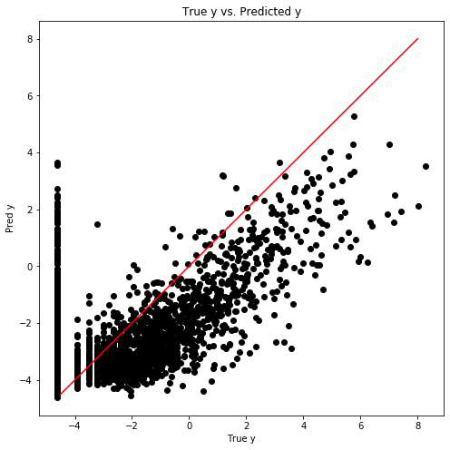

```python
#Plotting predicted values against true
plt.figure(figsize=(8,8))
plt.scatter (y_test, y_pred, c="k")
plt.plot([-4.5,8],[-4.5,8], c="r")
plt.title("True y vs. Predicted y")
plt.xlabel("True y")
plt.ylabel("Pred y")
plt.show()
```

It's clear that the model is really struggling with the abundance of zeros. They're resulting in a consistent underestimation of the uplift, which can be seen by the very visual misalignment of the "ideal" line compared to the actual points.

Meanwhile, the numbers that should be 0 are being predicted across almost the entire spectrum of predicted values.

And it looks even worse when we inverse transform the prediction back into the true values (i.e. the actual change in player numbers).

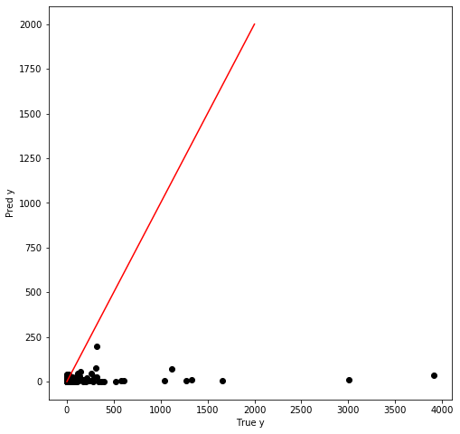

```python
plt.figure(figsize=(8,8))
plt.scatter ((np.exp(y_test)-0.01),(np.exp(y_pred)-0.01), c="k")
plt.plot([0,2000],[0,2000], c="r")
plt.xlabel("True y")
plt.ylabel("Pred y")
#plt.xlim((-50,2000))
plt.show()
```

```python
r2_score((np.exp(y_test)-0.01),(np.exp(y_pred)-0.01))
```

```
0.017123809442812887
```

Transforming the data in this way clearly isn't particularly successful, so a new approach needs to be taken.

Having a look at the feature importances does show that they make sense. The main predictors of uplift are generally directly, or indirectly, related to popularity: Other measures of player numbers, number of ratings (people on related games they've played) and price (smaller, independent, less popular games are going to be cheaper that those made by big-names).

Discount % is at least providing some of the predictive power, though at this stage very little.

```python
pd.DataFrame(tree_pipe.steps[3][1].feature_importances_, index=tree_pipe.steps[1][1].feature_names).sort_values(0, ascending=False).head(10)
```

|  | 0 |
| --- | --- |
| may_19_av | 0.312001 |
| jun_19_peak | 0.084192 |
| all_time_peak | 0.080647 |
| ratingpc | 0.069171 |
| jun_19_av | 0.068577 |
| total_ratings | 0.060533 |
| price | 0.054034 |
| may_jun_avuplift | 0.049698 |
| may_19_peak | 0.045705 |
| discount | 0.037317 |

# Predicting absolute values

In order to get around the issue of too many zeros, maybe it makes sense to completely change tack.

Rather than predicting the *change* in player numbers, perhaps I should just try and predict the actual number of players in the second month. You don't get negative people, so this will allow me to log transform the entire variable without issue (after adding a constant to account for zeros).

As such, for the next section my prediction variable has changed to the log transformation of average players in July.

```python
#creating new dataframe for prediction
steam_df_log2=steam_df.copy()

for var in ["all_time_peak", "may_19_av", "jun_19_av", "jul_19_av", "may_19_peak", "jun_19_peak", "total_ratings"]:
    steam_df_log2[var] = np.log(steam_df_log2[var].map(lambda x: x+0.01))
```

As it gave the best results before, I start with the Random Forest Regressor here

```python
X=steam_df_log2.copy()
y = X.pop("jul_19_av")
X_train, X_test, y_train, y_test = train_test_split(X, y, test_size=0.2, random_state=1)

dropper = Dropper(["index", "appid", "name", "developer", "publisher", "release_date",
                   "jun_jul_avupliftpc", "may_jun_avupliftpc", "jun_jul_avuplift", "may_jun_avuplift",
                  ])
dummier = Dummier(X, ["required_age"])
scaler = StandardScaler()
model = RandomForestRegressor(n_estimators=100)

tree_pipe = Pipeline(steps = [("dropper", dropper),
                              ("dummier", dummier),
                             ("scaler",scaler),
                             ("model", model)])

tree_pipe.fit(X_train, y_train)

scores = cross_val_score(tree_pipe, X_train, y_train, cv=5)

print("CV score: {0:.3f}".format(np.mean(scores)))
print("CV std = {0:.3f}".format(np.std(scores)))
print("")
print("Test score: {0:.3f}".format(tree_pipe.score(X_test, y_test)))
```

```
CV score: 0.941
CV std = 0.006

Test score: 0.947
```

Wow! R2 of .95!

...of course, nothing can be that easy, surely?

Maybe it's best to look at this deeper before celebrating too soon.

```python
y_pred = tree_pipe.predict(X_test)
```

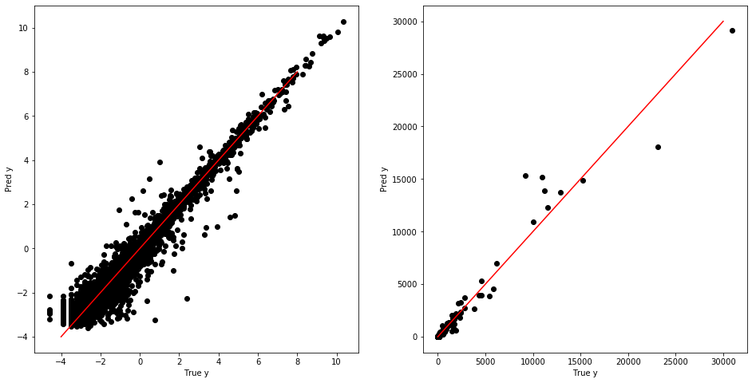

```python
fig, ax = plt.subplots(ncols=2,figsize=(16,8))

ax[0].scatter (y_test, y_pred, c="k")
ax[0].plot([-4,8],[-4,8], c="r")
ax[0].set_xlabel("True y")
ax[0].set_ylabel("Pred y")

plt.scatter((np.exp(y_test)-0.01),(np.exp(y_pred)-0.01),c="k")
plt.plot([0,30000],[0,30000], c="r")
ax[1].set_xlabel("True y")
ax[1].set_ylabel("Pred y")

plt.show()
```

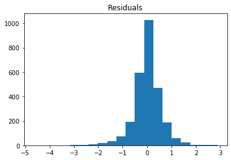

```python
plt.hist((y_pred)-(y_test), bins=20)
plt.title("Residuals")
plt.show()
```

```python
r2_score((np.exp(y_test)-0.01),(np.exp(y_pred)-0.01))
```

```
0.959893440681413
```

The true vs.predicted values look very well aligned when plotted, and the residuals aren't too badly distributed. It even keeps it's strong R2 score when transformed back into true values.

However, looking at the feature importances we can see that almost all predictive power of the model is coming from the average number of players in June

```python
pd.DataFrame([round(coef,4) for coef in tree_pipe.steps[3][1].feature_importances_], index=tree_pipe.steps[1][1].feature_names).sort_values(0, ascending=False).head(10)
```

|  | 0 |
| --- | --- |
| jun_19_av | 0.9323 |
| may_19_av | 0.0133 |
| all_time_peak | 0.0108 |
| ratingpc | 0.0064 |
| total_ratings | 0.0061 |
| jun_19_peak | 0.0060 |
| price | 0.0049 |
| may_19_peak | 0.0046 |
| discount | 0.0032 |
| gen_Casual | 0.0008 |

At this point, as we're predicting the total player numbers for the next month, the problem has mostly turned into a timeseries one. And it would appear that there are some pretty strong autocorrelations within the data. The best way to deal with this in a timeseries would be to transform the data into differences, but... that's exactly what I was trying to solve by doing this.

Even though almost all of the predictive power is coming form the previous month, this could still be a useful model if the additional variables do make it more accurate than simply looking at the past month's numbers. As such, the new evaluation metric will be looking at the accuracy of how the model predicts July numbers compared to the accuracy of just taking the June numbers.

As such, I created a modified R2 score which compares the mean squared error of the model to the mean squared error from the previous month's numbers

```python
def mod_r2(y_true, y_pred, X):
    """Compares the accuracy of a model to another variable"""
    from sklearn.metrics import mean_squared_error

    return 1-(mean_squared_error(y_true, y_pred) / mean_squared_error(y_true, X))
```

```python
#r2 score vs. jun
mod_r2(y_test,y_pred, X_test["jun_19_av"])
```

```
0.21615582584080395
```

```python
#actual (unlogged) r2 score vs. jun
mod_r2((np.exp(y_test)-0.01),(np.exp(y_pred)-0.01), np.exp(X_test["jun_19_av"])-0.01)
```

```
0.100693900511722
```

The R2 score for the log and actual values look a loss less impressive now that they are compared to the Jun values. But considering the strong baseline the score doesn't need to be especially impressive to still be useful.

By taking the predictive power of June out of the model, I am now effectively back to predicting the uplift between the months (in fact, running a standard R2 on the uplift based on this model's predictions vs. reality gets an almost identical value to the modifies R2 above).

So as before we can look at the difference between the predicted and real uplift generated by this model, and see if that provides any information to go forwards

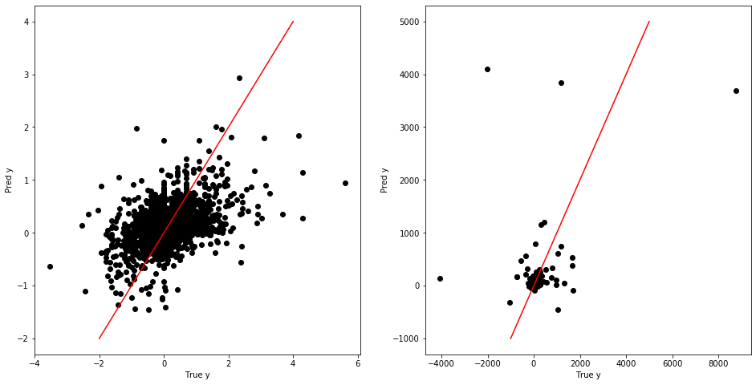

```python
fig, ax = plt.subplots(ncols=2,figsize=(16,8))

ax[0].scatter(y_test-X_test["jun_19_av"],y_pred-X_test["jun_19_av"], c="k")
ax[0].plot([-2,4],[-2,4], c="r")
ax[0].set_xlabel("True y")
ax[0].set_ylabel("Pred y")

plt.scatter((np.exp(y_test)-0.01)-(np.exp(X_test["jun_19_av"])-0.01),
            (np.exp(y_pred)-0.01)-(np.exp(X_test["jun_19_av"])-0.01),c="k")
plt.plot([-1000,5000],[-1000,5000], c="r")
ax[1].set_xlabel("True y")
ax[1].set_ylabel("Pred y")

plt.show()
```

And looking at where the biggest residuals are:

```python
X_test["resid"] = (np.exp(y_pred)-0.01) - (np.exp(y_test)-0.01)
X_test["target"]= (np.exp(y_test)-0.01)
X_test["jun_19_av"] = np.exp(X_test["jun_19_av"])-0.01
X_test["pred"] = np.exp(y_pred)-0.01
X_test["pred_uplift"] = X_test["pred"]-X_test["jun_19_av"]
X_test["real_uplift"] = X_test["target"]-X_test["jun_19_av"]
X_test["uplift_resid"] = X_test["pred_uplift"] - X_test["real_uplift"]
X_test["absolute_resid"] = [abs(i) for i in X_test["uplift_resid"]]
```

```python
X_test[["appid", "name", "discount", "jun_19_av",
        "target", "pred", "resid", "real_uplift",
        "pred_uplift", "uplift_resid", "absolute_resid"]] \
.sort_values("absolute_resid", ascending=False).head(15)
```

|  | appid | name | discount | jun_19_av | target | pred | resid | real_uplift | pred_uplift | uplift_resid | absolute_resid |
| --- | --- | --- | --- | --- | --- | --- | --- | --- | --- | --- | --- |
| 3272 | 322330 | Don't Starve Together | 60.0 | 11238.05 | 9219.31 | 15345.200418 | 6125.890418 | -2018.74 | 4107.150418 | 6125.890418 | 6125.890418 |
| 649 | 39210 | FINAL FANTASY XIV Online | 0.0 | 14339.24 | 23105.44 | 18029.717571 | -5075.722429 | 8766.20 | 3690.477571 | -5075.722429 | 5075.722429 |
| 2308 | 281990 | Stellaris | 75.0 | 15030.93 | 10976.16 | 15164.574862 | 4188.414862 | -4054.77 | 133.644862 | 4188.414862 | 4188.414862 |
| 17 | 550 | Left 4 Dead 2 | 80.0 | 10076.32 | 11248.62 | 13924.381623 | 2675.761623 | 1172.30 | 3848.061623 | 2675.761623 | 2675.761623 |
| 107 | 4000 | Garry's Mod | 75.0 | 29240.97 | 30954.39 | 29144.811997 | -1809.578003 | 1713.42 | -96.158003 | -1809.578003 | 1809.578003 |
| 1573 | 242760 | The Forest | 0.0 | 4353.57 | 5398.07 | 3900.766129 | -1497.303871 | 1044.50 | -452.803871 | -1497.303871 | 1497.303871 |
| 1198 | 211820 | Starbound | 35.0 | 4177.90 | 5837.10 | 4554.398177 | -1282.701823 | 1659.20 | 376.498177 | -1282.701823 | 1282.701823 |
| 6914 | 480490 | Prey | 0.0 | 570.80 | 1898.43 | 624.913564 | -1273.516436 | 1327.63 | 54.113564 | -1273.516436 | 1273.516436 |
| 4465 | 367520 | Hollow Knight | 40.0 | 2160.58 | 3819.60 | 2692.054812 | -1127.545188 | 1659.02 | 531.474812 | -1127.545188 | 1127.545188 |
| 3006 | 311690 | Enter the Gungeon | 50.0 | 2699.46 | 2136.73 | 3173.654353 | 1036.924353 | -562.73 | 474.194353 | 1036.924353 | 1036.924353 |
| 13380 | 960090 | Bloons TD 6 | 30.0 | 538.29 | 1518.83 | 553.192626 | -965.637374 | 980.54 | 14.902626 | -965.637374 | 965.637374 |
| 12225 | 834910 | ATLAS | 67.0 | 3565.52 | 2816.61 | 3736.936139 | 920.326139 | -748.91 | 171.416139 | 920.326139 | 920.326139 |
| 2606 | 294100 | RimWorld | 0.0 | 10375.04 | 10041.86 | 10932.668394 | 890.808394 | -333.18 | 557.628394 | 890.808394 | 890.808394 |
| 8371 | 552500 | Warhammer: Vermintide 2 | 66.0 | 3112.17 | 2389.22 | 3274.740616 | 885.520616 | -722.95 | 162.570616 | 885.520616 | 885.520616 |
| 6105 | 438740 | Friday the 13th: The Game | 80.0 | 699.68 | 1670.09 | 801.807875 | -868.282125 | 970.41 | 102.127875 | -868.282125 | 868.282125 |

The size of the residuals quickly drops off, suggesting that most of the inaccuracy is coming from a few predictions. And these tend to come from games that are among the most popular.

So perhaps by restricting the games included in a model by current player numbers it's possible to make a more stable model?

Below I slowly restrict games more and more to see if there is an optimal upper value to create a model with

```python
#generate some dataframes to save our scores
new_r2_df = pd.DataFrame()
unlogged_new_r2_df = pd.DataFrame()

#cycle through player numbers to restrict games by
for i in tqdm_notebook([np.exp(i) for i in range(11,-1,-1)]):

    #create lists to save scores per restriction
    new_r2 = []
    unlogged_new_r2 = []

    #cycle several times to check stability
    for n in range(11):

        #filtering dataframe
        X=steam_df_log2[steam_df_log2["jun_19_av"] <np.log(i+0.01)].copy()
        y = X.pop("jul_19_av")

        #random state undefinied allows for different split each time to check stability
        X_train, X_test, y_train, y_test = train_test_split(X, y, test_size=0.2)


        #instatiating pipeline classes
        dropper = Dropper(["index", "appid", "name", "developer", "publisher", "release_date",
                           "jun_jul_avupliftpc", "may_jun_avupliftpc", "jun_jul_avuplift", "may_jun_avuplift",
                          ])
        dummier = Dummier(X, ["required_age"])
        scaler = StandardScaler()
        model = RandomForestRegressor(n_estimators=50)

        tree_pipe = Pipeline(steps = [("dropper", dropper),
                                      ("dummier", dummier),
                                      ("scaler",scaler),
                                      ("model", model)])


        #fitting and getting predictions/scores
        tree_pipe.fit(X_train, y_train)
        y_pred = tree_pipe.predict(X_test)

        new_r2.append(mod_r2(y_test, y_pred, X_test["jun_19_av"]))
        unlogged_new_r2.append(mod_r2(np.exp(y_test)-0.01, np.exp(y_pred)-0.01, np.exp(X_test["jun_19_av"]-0.01)))


    #adding scores to dataframe
    new_r2_df[i] = new_r2
    unlogged_new_r2_df[i] = unlogged_new_r2
```

Looking at the scores by upper limit of player number, around 3000 is it seems to reach a good balance of mean/std while cutting off as few games as possible (it still keeps over 99% of the games)

```python
#mean and std of mod r2 scores by filter limit
unlogged_new_r2_df.describe().T[["mean", "std"]]
```

|  | mean | std |
| --- | --- | --- |
| 59874.141715 | -1.265772 | 2.265404 |
| 22026.465795 | -0.147071 | 0.619741 |
| 8103.083928 | -0.188410 | 0.327606 |
| 2980.957987 | 0.283897 | 0.137984 |
| 1096.633158 | 0.104301 | 0.101096 |
| 403.428793 | 0.117477 | 0.123642 |
| 148.413159 | 0.217984 | 0.097264 |
| 54.598150 | 0.116384 | 0.089431 |
| 20.085537 | 0.009816 | 0.026348 |
| 7.389056 | 0.037671 | 0.027213 |
| 2.718282 | 0.096195 | 0.085181 |
| 1.000000 | -0.019998 | 0.082336 |

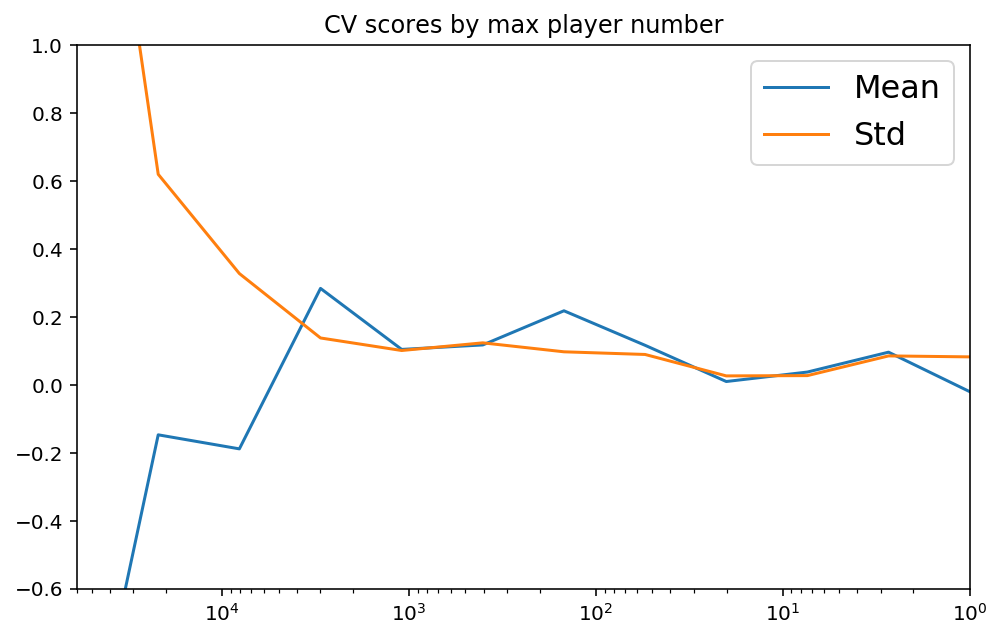

```python
#plot of the above
plt.figure(figsize=(8,5))
plt.plot([np.exp(i) for i in range(11,-1,-1)], unlogged_new_r2_df.describe().T[["mean"]],label="Mean")
plt.plot([np.exp(i) for i in range(11,-1,-1)], unlogged_new_r2_df.describe().T[["std"]], label="Std")
plt.xscale("log")
plt.xlim(60000, 1)
plt.ylim(-0.6, 1)
plt.title("CV scores by max player number")
plt.legend(fontsize=16)
plt.show()
```

```python
#proportion of games still kept with the filter of 3000
((steam_df["jun_19_av"] <3000).sum()/len(steam_df))
```

```
0.9949107537984954
```

```python
randint
```

So taking all of this into account, one final model search to find the optimal type of model:

```python
#Due to using my own evaluation function, I need to create my own CV test

#assigning a random state so all model are compared on even ground:
state=random.randint(1,100)

#Cycling therough several models to compare performance
for i,model in enumerate([LinearRegression(), Ridge(), Lasso(), RandomForestRegressor(n_estimators=50),
                             GradientBoostingRegressor(), DecisionTreeRegressor(), AdaBoostRegressor(),
                             ExtraTreesRegressor(n_estimators=100), BaggingRegressor()]):

    #creating lists to hold scores
    cv_modr2 = []
    cv_modr2_actual = []

    #filtering data and splitting out target
    X=steam_df_log2[steam_df_log2["jun_19_av"]< np.log(3000+0.01)].copy()
    y = X.pop("jul_19_av")


    X_train, X_test, y_train, y_test = train_test_split(X, y, test_size=0.2, random_state=state)

    #setting up classes and pipelines
    dropper = Dropper(["index", "appid", "name", "developer", "publisher", "release_date",
                       "jun_jul_avupliftpc", "may_jun_avupliftpc", "jun_jul_avuplift", "may_jun_avuplift",
                      ])
    dummier = Dummier(X, ["required_age"])
    scaler = StandardScaler()
    model = model
    best_ridge = RidgeCV(alphas = np.logspace(-5,5,100), cv=10)
    best_lasso = LassoCV(n_alphas = 100, cv=5)


    pipe = Pipeline(steps = [("dropper", dropper),
                                  ("dummier", dummier),
                                 ("scaler",scaler),
                                 ("model", model)])

    lasso_pipe = Pipeline(steps = [("dropper", dropper),
                             ("dummier", dummier),
                             ("scaler",scaler),
                             ("best_laso", best_lasso)])

    ridge_pipe = Pipeline(steps = [("dropper", dropper),
                             ("dummier", dummier),
                             ("scaler",scaler),
                             ("best_ridge", best_ridge)])

    #cross-validating train set
    for n in range(6):
        X_train2, X_test2, y_train2, y_test2 = train_test_split(X_train, y_train, test_size=0.2, random_state=n)

        #addin in a CV for regularisation level of Ridge and Lasso
        if i == 1:
            model = Ridge(alpha =ridge_pipe.fit(X_train2, y_train2).steps[3][1].alpha_)
        elif i == 2:
            model = Lasso(alpha =lasso_pipe.fit(X_train2, y_train2).steps[3][1].alpha_)
        else:
            pass

        pipe.fit(X_train2, y_train2)
        y_pred2 = pipe.predict(X_test2)

        cv_modr2.append(mod_r2(y_test2,y_pred2, X_test2["jun_19_av"]))
        cv_modr2_actual.append(mod_r2(np.exp(y_test2)-0.01,np.exp(y_pred2)-0.01, np.exp(X_test2["jun_19_av"])-0.01))

    #After cross-validatin train set, running test
    if i == 1:
        model = Ridge(alpha =ridge_pipe.fit(X_train, y_train).steps[3][1].alpha_)
    elif i == 2:
        model = Lasso(alpha =lasso_pipe.fit(X_train, y_train).steps[3][1].alpha_)
    else:
        pass

    pipe.fit(X_train, y_train)
    y_pred = pipe.predict(X_test)

    print(model)
    print("CV Mod R2 mean: {0:.3f}\t CV mod R2 std: {1:.3f}".format(np.mean(cv_modr2), np.std(cv_modr2)))
    print("CV Mod R2a mean: {0:.3f}\t CV mod R2a std: {1:.3f}".format(np.mean(cv_modr2_actual), np.std(cv_modr2_actual)))
    print("")
    print("Test Mod R2: {0:.3f}".format(mod_r2(y_test,y_pred, X_test["jun_19_av"])))
    print("TestMod R2 (actual): {0:.3f}".format(mod_r2((np.exp(y_test)-0.01),(np.exp(y_pred)-0.01), np.exp(X_test["jun_19_av"])-0.01)))
    print("")
```

```
LinearRegression(copy_X=True, fit_intercept=True, n_jobs=None, normalize=False)
CV Mod R2 mean: 0.159	 CV mod R2 std: 0.014
CV Mod R2a mean: -0.007	 CV mod R2a std: 0.138

Test Mod R2: 0.170
TestMod R2 (actual): 0.022

Ridge(alpha=2.848035868435799, copy_X=True, fit_intercept=True, max_iter=None,
      normalize=False, random_state=None, solver='auto', tol=0.001)
CV Mod R2 mean: 0.158	 CV mod R2 std: 0.014
CV Mod R2a mean: -0.008	 CV mod R2a std: 0.138

Test Mod R2: 0.170
TestMod R2 (actual): 0.023

Lasso(alpha=0.0022916439121582564, copy_X=True, fit_intercept=True,
      max_iter=1000, normalize=False, positive=False, precompute=False,
      random_state=None, selection='cyclic', tol=0.0001, warm_start=False)
CV Mod R2 mean: -2.221	 CV mod R2 std: 0.136
CV Mod R2a mean: -14.964	 CV mod R2a std: 5.388

Test Mod R2: -2.311
TestMod R2 (actual): -9.220

RandomForestRegressor(bootstrap=True, criterion='mse', max_depth=None,
                      max_features='auto', max_leaf_nodes=None,
                      min_impurity_decrease=0.0, min_impurity_split=None,
                      min_samples_leaf=1, min_samples_split=2,
                      min_weight_fraction_leaf=0.0, n_estimators=50,
                      n_jobs=None, oob_score=False, random_state=None,
                      verbose=0, warm_start=False)
CV Mod R2 mean: 0.202	 CV mod R2 std: 0.023
CV Mod R2a mean: 0.136	 CV mod R2a std: 0.188

Test Mod R2: 0.203
TestMod R2 (actual): 0.274

GradientBoostingRegressor(alpha=0.9, criterion='friedman_mse', init=None,
                          learning_rate=0.1, loss='ls', max_depth=3,
                          max_features=None, max_leaf_nodes=None,
```

[output cut: 38 more lines]

```
CV Mod R2 mean: 0.196	 CV mod R2 std: 0.018
CV Mod R2a mean: 0.165	 CV mod R2a std: 0.196

Test Mod R2: 0.222
TestMod R2 (actual): 0.285

BaggingRegressor(base_estimator=None, bootstrap=True, bootstrap_features=False,
                 max_features=1.0, max_samples=1.0, n_estimators=10,
                 n_jobs=None, oob_score=False, random_state=None, verbose=0,
                 warm_start=False)
CV Mod R2 mean: 0.139	 CV mod R2 std: 0.034
CV Mod R2a mean: -0.024	 CV mod R2a std: 0.271

Test Mod R2: 0.147
TestMod R2 (actual): 0.201
```

Optimisation/gridsearching both of them may allow some further accuracy to be squeezed out, but I would be very surprised if the scores shift significantly